# RED WINE EXPLORATION by Yukti Sareen

```
##   X fixed.acidity volatile.acidity citric.acid residual.sugar chlorides
## 1 1           7.4             0.70        0.00            1.9     0.076
## 2 2           7.8             0.88        0.00            2.6     0.098
## 3 3           7.8             0.76        0.04            2.3     0.092
## 4 4          11.2             0.28        0.56            1.9     0.075
## 5 5           7.4             0.70        0.00            1.9     0.076
## 6 6           7.4             0.66        0.00            1.8     0.075
##   free.sulfur.dioxide total.sulfur.dioxide density   pH sulphates alcohol
## 1                  11                   34  0.9978 3.51      0.56     9.4
## 2                  25                   67  0.9968 3.20      0.68     9.8
## 3                  15                   54  0.9970 3.26      0.65     9.8
## 4                  17                   60  0.9980 3.16      0.58     9.8
## 5                  11                   34  0.9978 3.51      0.56     9.4
## 6                  13                   40  0.9978 3.51      0.56     9.4
##   quality
## 1       5
## 2       5
## 3       5
## 4       6
## 5       5
## 6       5
```

```
## 'data.frame':    1599 obs. of  13 variables:
##  $ X                   : int  1 2 3 4 5 6 7 8 9 10 ...
##  $ fixed.acidity       : num  7.4 7.8 7.8 11.2 7.4 7.4 7.9 7.3 7.8 7.5 ...
##  $ volatile.acidity    : num  0.7 0.88 0.76 0.28 0.7 0.66 0.6 0.65 0.58 0.5 ...
##  $ citric.acid         : num  0 0 0.04 0.56 0 0 0.06 0 0.02 0.36 ...
##  $ residual.sugar      : num  1.9 2.6 2.3 1.9 1.9 1.8 1.6 1.2 2 6.1 ...
##  $ chlorides           : num  0.076 0.098 0.092 0.075 0.076 0.075 0.069 0.065 0.073 0.071 ...
##  $ free.sulfur.dioxide : num  11 25 15 17 11 13 15 15 9 17 ...
##  $ total.sulfur.dioxide: num  34 67 54 60 34 40 59 21 18 102 ...
##  $ density             : num  0.998 0.997 0.997 0.998 0.998 ...
##  $ pH                  : num  3.51 3.2 3.26 3.16 3.51 3.51 3.3 3.39 3.36 3.35 ...
##  $ sulphates           : num  0.56 0.68 0.65 0.58 0.56 0.56 0.46 0.47 0.57 0.8 ...
##  $ alcohol             : num  9.4 9.8 9.8 9.8 9.4 9.4 9.4 10 9.5 10.5 ...
##  $ quality             : int  5 5 5 6 5 5 5 7 7 5 ...
```

> I have decided to expolore the red vine quality data. This dataset has 13 variables and 1599 observations. There are 11 independent variables and 1 dependent.

# Univariate Plots Section

> Based on basic exploration, I will convert “Quality” variable from integer to factor variable.Secondly, plot the distrubution of all the variables to understand the basic distribution and tranform them if it consists of outliers.

```
## 'data.frame':    1599 obs. of  13 variables:
##  $ X                   : int  1 2 3 4 5 6 7 8 9 10 ...
##  $ fixed.acidity       : num  7.4 7.8 7.8 11.2 7.4 7.4 7.9 7.3 7.8 7.5 ...
##  $ volatile.acidity    : num  0.7 0.88 0.76 0.28 0.7 0.66 0.6 0.65 0.58 0.5 ...
##  $ citric.acid         : num  0 0 0.04 0.56 0 0 0.06 0 0.02 0.36 ...
##  $ residual.sugar      : num  1.9 2.6 2.3 1.9 1.9 1.8 1.6 1.2 2 6.1 ...
##  $ chlorides           : num  0.076 0.098 0.092 0.075 0.076 0.075 0.069 0.065 0.073 0.071 ...
##  $ free.sulfur.dioxide : num  11 25 15 17 11 13 15 15 9 17 ...
##  $ total.sulfur.dioxide: num  34 67 54 60 34 40 59 21 18 102 ...
##  $ density             : num  0.998 0.997 0.997 0.998 0.998 ...
##  $ pH                  : num  3.51 3.2 3.26 3.16 3.51 3.51 3.3 3.39 3.36 3.35 ...
##  $ sulphates           : num  0.56 0.68 0.65 0.58 0.56 0.56 0.46 0.47 0.57 0.8 ...
##  $ alcohol             : num  9.4 9.8 9.8 9.8 9.4 9.4 9.4 10 9.5 10.5 ...
##  $ quality             : Ord.factor w/ 6 levels "3"<"4"<"5"<"6"<..: 3 3 3 4 3 3 3 5 5 3 ...
```

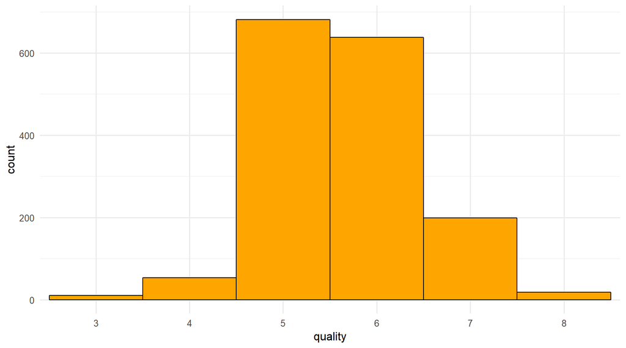

Most wine in the dataset have quality between 5 and 6.

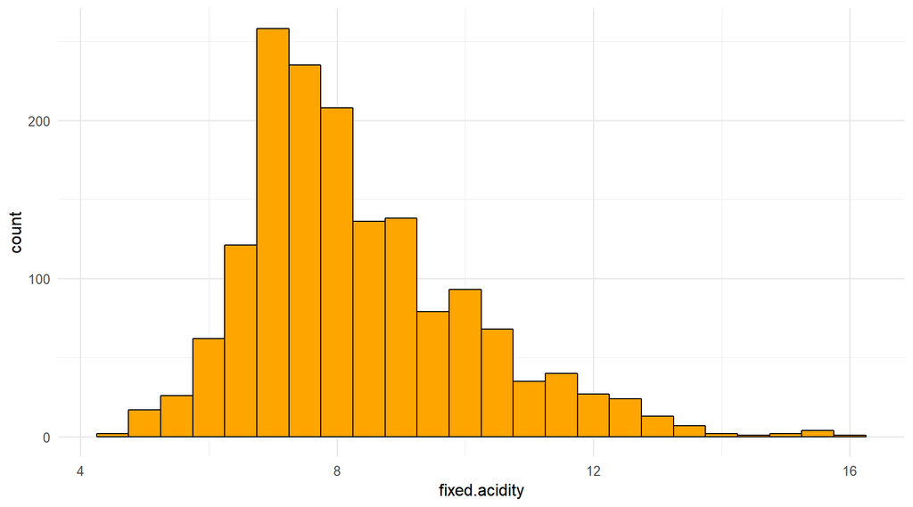

```
##    Min. 1st Qu.  Median    Mean 3rd Qu.    Max.
##    4.60    7.10    7.90    8.32    9.20   15.90
```

The distribution of Fixed Acidity is positively skewed. The median is around 8 with high concentration of wines with Fixed Acidity but due to some outliers, the mean has been dragged to around 8.32.

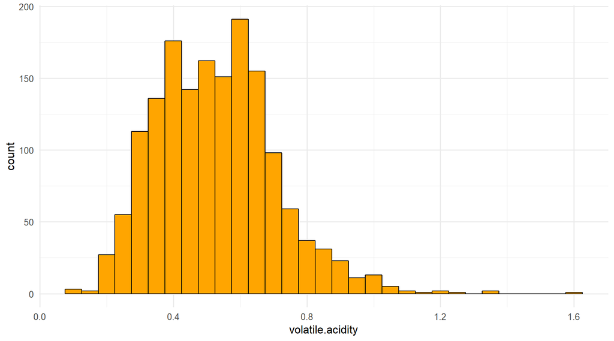

```
##    Min. 1st Qu.  Median    Mean 3rd Qu.    Max.
##  0.1200  0.3900  0.5200  0.5278  0.6400  1.5800
```

The distribution of volatile acidity graph is bimodal and is close to noraml distribution with peaks at 0.4 and 0.6.

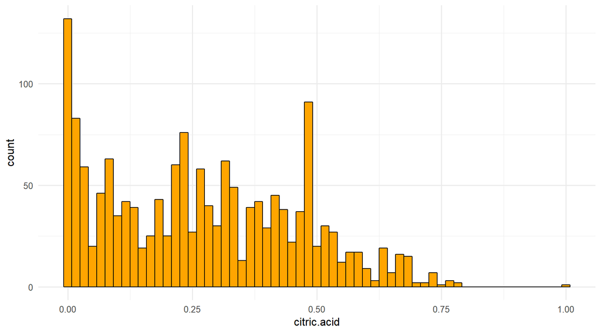

```
##    Min. 1st Qu.  Median    Mean 3rd Qu.    Max.
##   0.000   0.090   0.260   0.271   0.420   1.000
```

The distribution of citric acid is divided in two decreasing trends, 0 to 0.25 and 0.5 to 0.75 with values missing in the higher range.

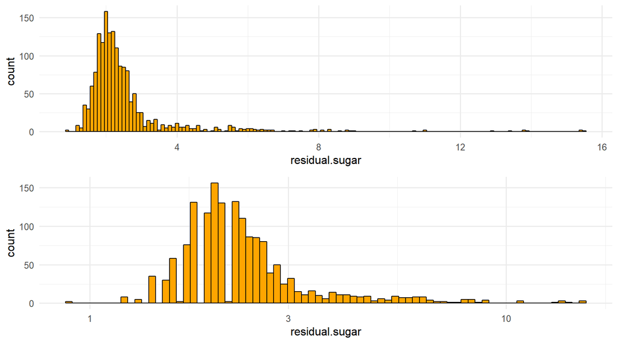

```
##    Min. 1st Qu.  Median    Mean 3rd Qu.    Max.
##   0.900   1.900   2.200   2.539   2.600  15.500
```

Based on the dataset description about the residual sugar, since it is rare to find wines with less than 1 gram/liter and wines with greater than 45 grams/liter are considered sweet. The right skewed plot and outliers were converted by plotting the log transformation.

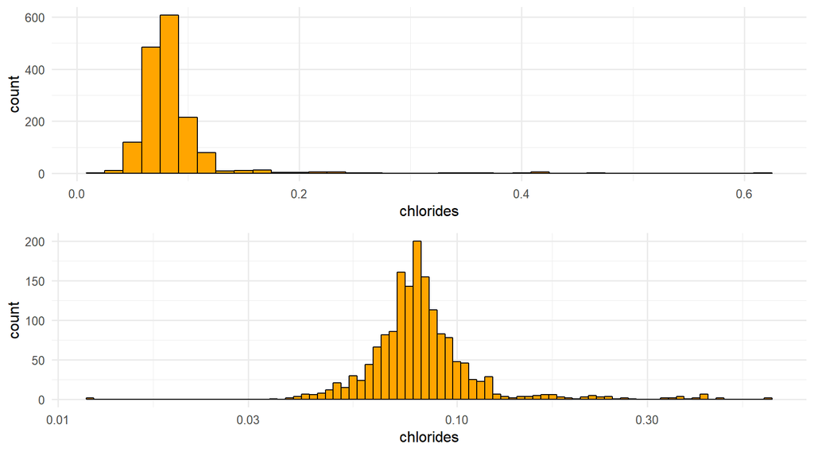

```
##    Min. 1st Qu.  Median    Mean 3rd Qu.    Max.
## 0.01200 0.07000 0.07900 0.08747 0.09000 0.61100
```

Similar to residual sugar, chlorides were transformed using log and mostly present in wine in range of 0.04 to 0.11

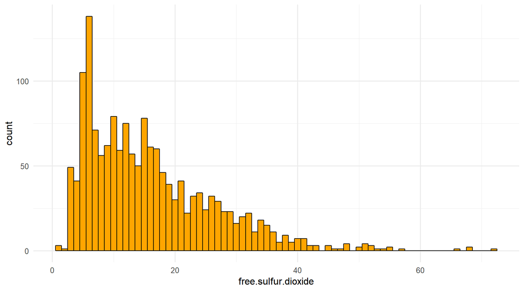

```
##    Min. 1st Qu.  Median    Mean 3rd Qu.    Max.
##    1.00    7.00   14.00   15.87   21.00   72.00
```

The distribution of the free sulphur dioxide was severly right skewed with 75% of the values falling wihin 21.

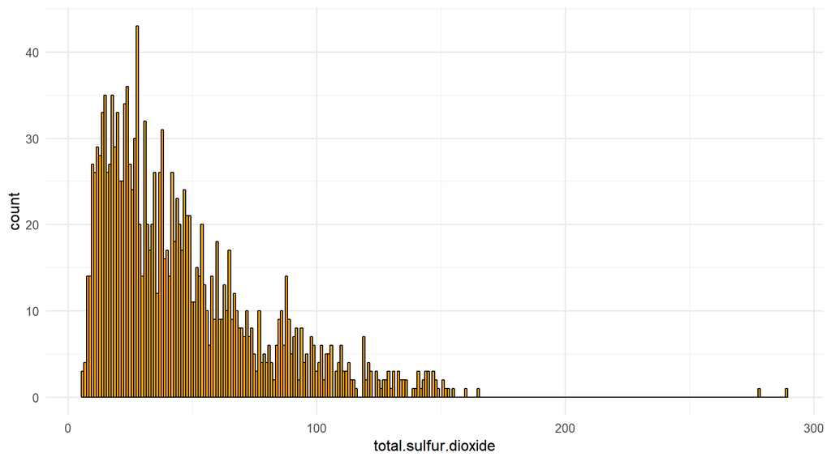

```
##    Min. 1st Qu.  Median    Mean 3rd Qu.    Max.
##    6.00   22.00   38.00   46.47   62.00  289.00
```

The distribution of the total sulphur dioxide is similar to free SO2 -severly right skewed, since free SO2 is subset of total SO2.

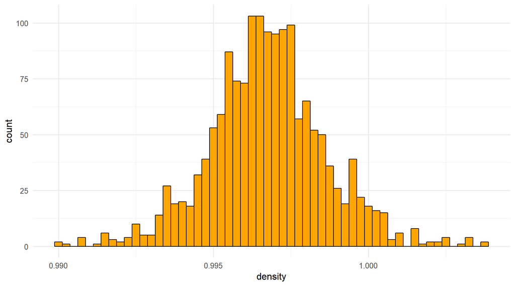

```
##    Min. 1st Qu.  Median    Mean 3rd Qu.    Max.
##  0.9901  0.9956  0.9968  0.9967  0.9978  1.0037
```

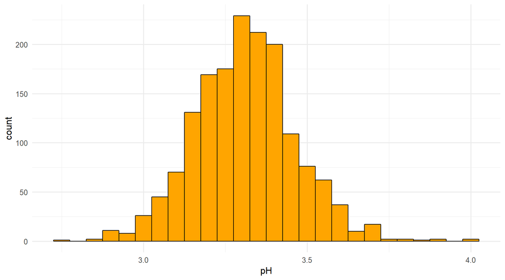

```
##    Min. 1st Qu.  Median    Mean 3rd Qu.    Max.
##   2.740   3.210   3.310   3.311   3.400   4.010
```

The distribution of the ph values in wine display that most wine have ph value between 3 and 3.7.

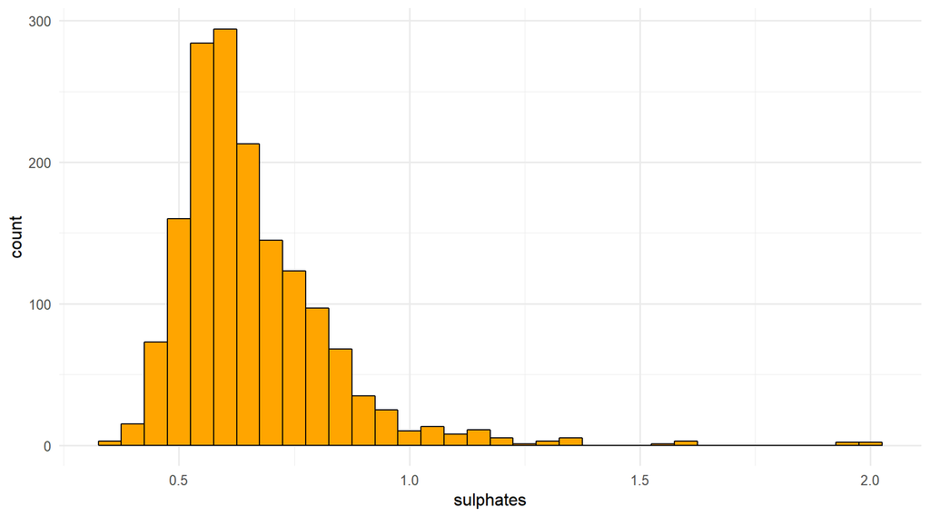

```
##    Min. 1st Qu.  Median    Mean 3rd Qu.    Max.
##  0.3300  0.5500  0.6200  0.6581  0.7300  2.0000
```

The distribution of the sulphates in wine display that most wine have sulphates between 0.5 to 1 and has few outliers.

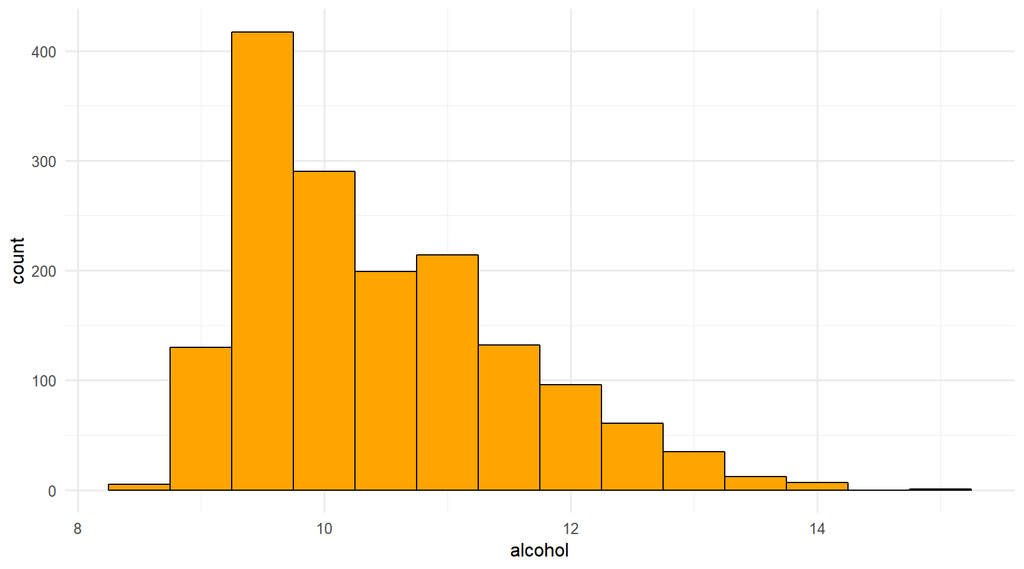

```
##    Min. 1st Qu.  Median    Mean 3rd Qu.    Max.
##    8.40    9.50   10.20   10.42   11.10   14.90
```

The distribution of the red wine dataset displays that most wine in the data set have alcohol content highest as 10% but few around 8.4% and few as high as 14% .

# Univariate Analysis

### What is the structure of your dataset?

The Red Wine Dataset had 1599 rows and 13 columns originally. Here the categorical variable is ‘quality’, and the rest of the variables are numerical variables which reflect the physical and chemical properties of the wine.

### What is/are the main feature(s) of interest in your dataset?

How the quality of the wine is determined by the numerical variables present in the dataset.

### What other features in the dataset do you think will help support your investigation into your feature(s) of interest?

Additional information on the quality of the wine can help us predict the model accurately.

### Of the features you investigated, were there any unusual distributions?

I cleaned the plots which were skewed and had outliers present in them, doing so helped me look into the data which was of more detailed.

# Bivariate Plots Section

```
##  [1] "fixed.acidity"        "volatile.acidity"     "citric.acid"
##  [4] "residual.sugar"       "chlorides"            "free.sulfur.dioxide"
##  [7] "total.sulfur.dioxide" "density"              "pH"
## [10] "sulphates"            "alcohol"
```

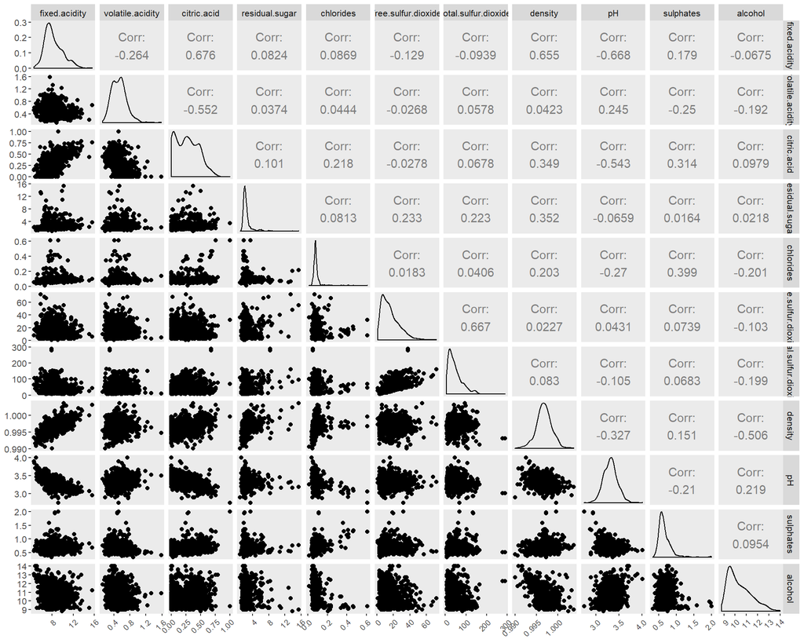

Based on the correlation matrix, Strong relationships between ph vs fixed acidity, citric acid vs fixed acidity, density to fixed acidity, total.SO2 vs free.SO2 are identified

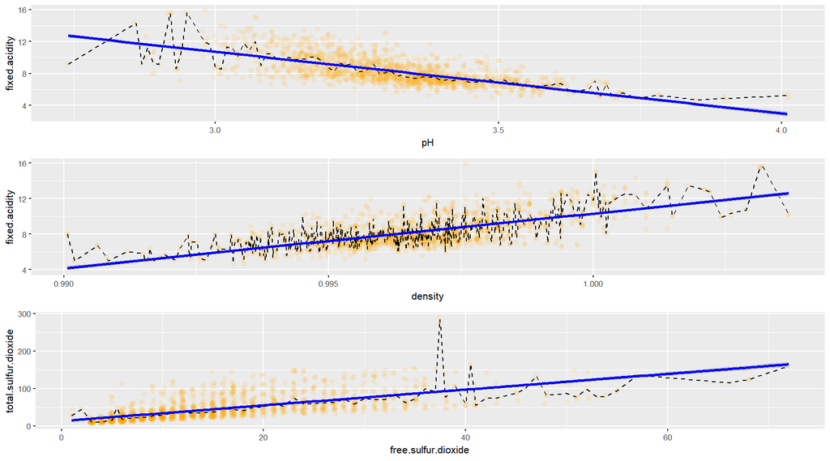

Top observations: 1. As per the wine data, for ph vs fixed acidity, most of the wines have ph levels between 3 - 4. Due to outliers the median line has a high variance. However, there is negative co-relation between ph and fixed acitdity around 3.2 to 3.5 when a linear line is plotted.

Lets analyse the acidic data.

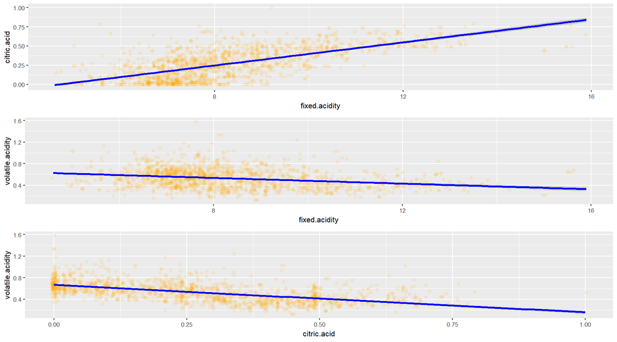

Lets analyse relationships of alcohol, ph, citric acid, volatile acidity, chlorides to quality using box plots

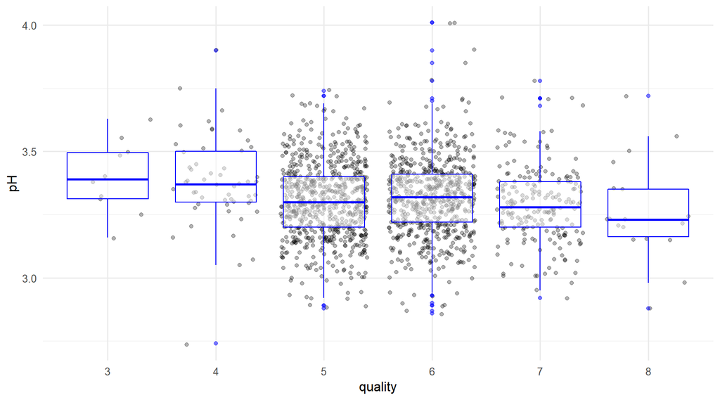

The quality to pH shows that overall pH decrease when quality level increases.

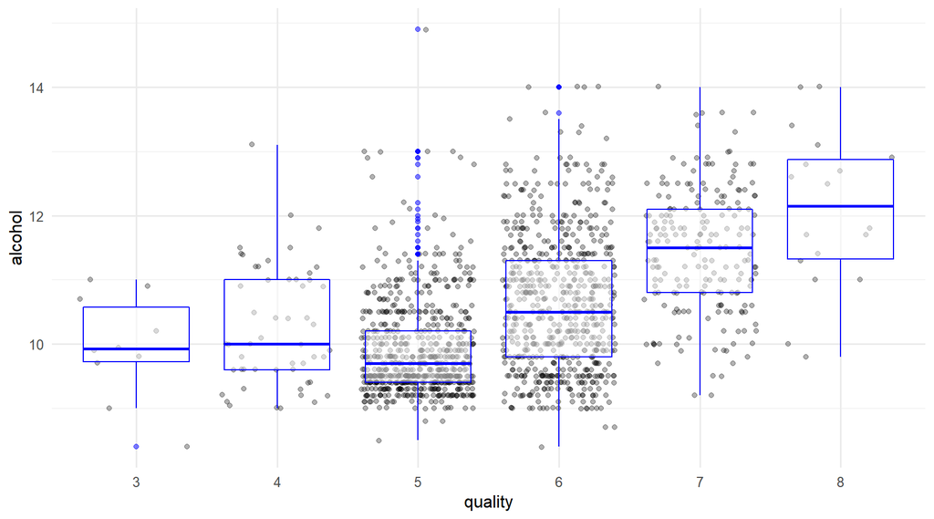

In the quality to alcohol, alcohol appears in the quality level 3 to 5, median keeps sames interval but drastically increase up at level 6 to 8.

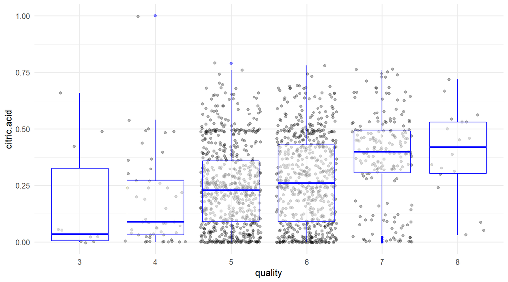

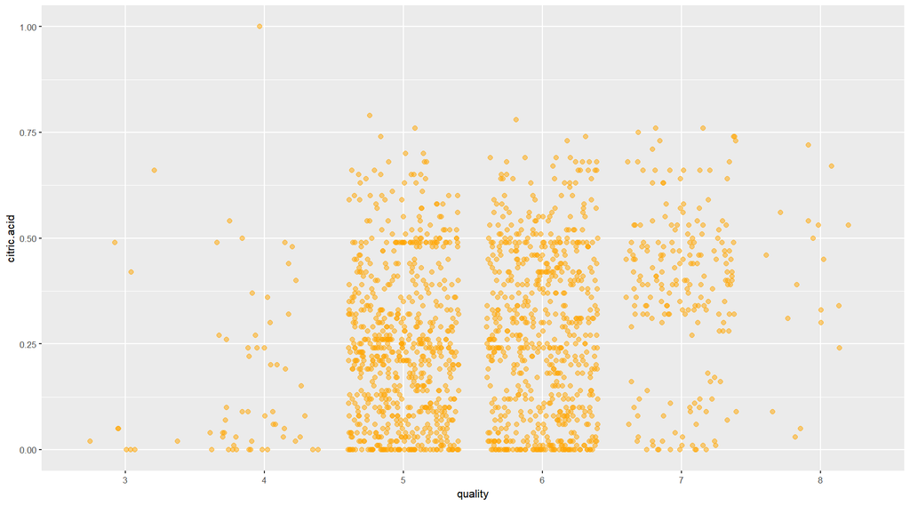

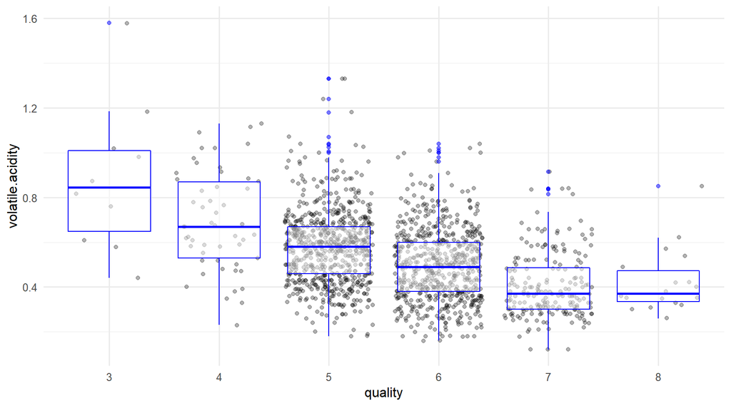

The quality to volatile acidity, the median of volatile acidity become lower and lower when quaity level increase.

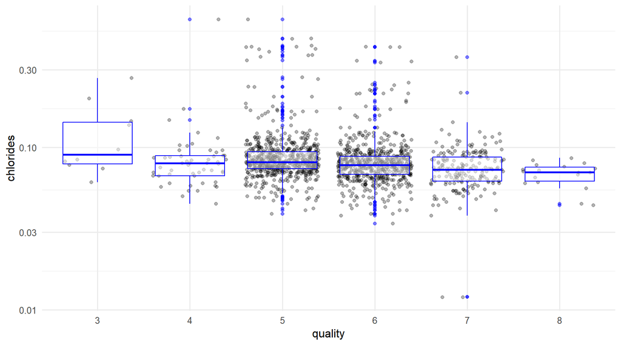

The chloride levels are the lowest in the highest quality wine. But quality 5-6 seems to have more outliers and could be interesting to deep dive into this.

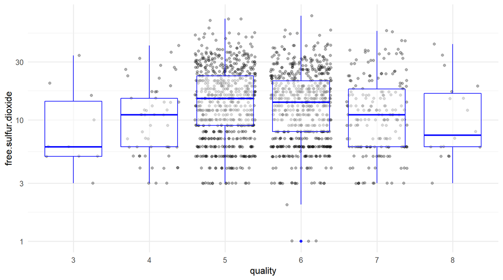

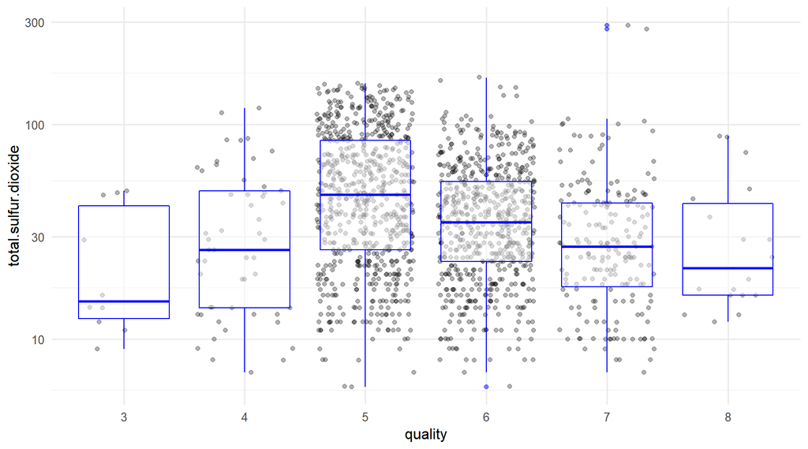

Lets plot the relationship between sulphates and sulpher dioxide itself. This can give us an idea if the sulphates that is a wine additive can contribute to sulfur dioxide gas (S02) levels.

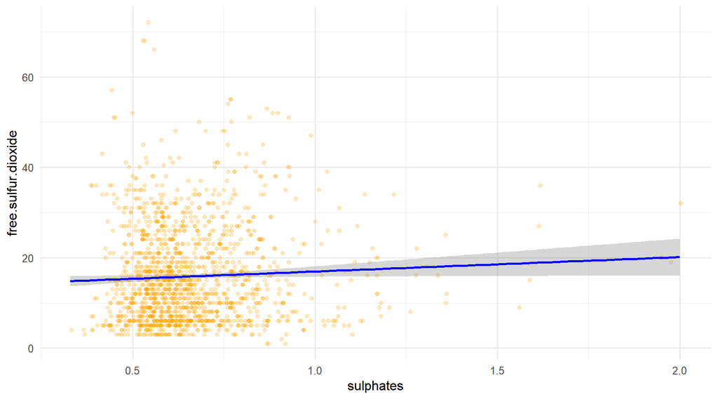

There is no relationship between sulphates and free SO2

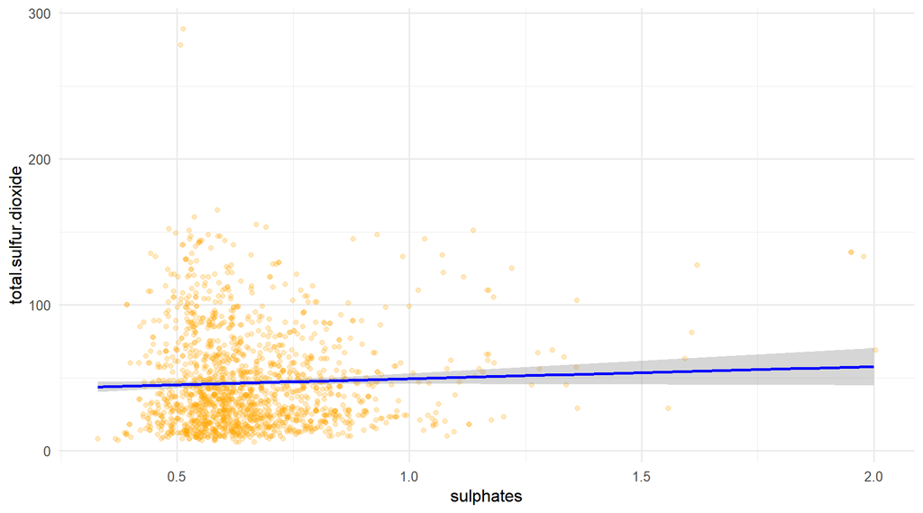

Similar to free SO2, there is no relationship between sulphates and total SO2

# Bivariate Analysis

### Talk about some of the relationships you observed in this part of the investigation. How did the feature(s) of interest vary with other features in the dataset?

In this Bivariate analysis, we can notice that some reasonable inference still make sence in this dataset, like more acid cause to lower pH value, and free SO2 is postive related to total amount of SO2. among the each attributes to quality, fixed acidity, volatile acidity, pH and alcohol affected the quality level in some degree.

### Did you observe any interesting relationships between the other features (not the main feature(s) of interest)?

The comparison between similar variable(so2, acid) also explored interesting result such as fixed acidity with citric acid are positive relative but many of others are not related.

### What was the strongest relationship you found?

At the beginning of bivariate part, there are four largest absolute value correlation value, which are pH to fixed acidity, citric acid to fixed acidity, total sulfur dioxide to free sulfur dioxide, and density to fixed acidity. These sets are the top four strongest relation ship in original dataset.

# Multivariate Plots Section

First graph is about ph to fixed acidity and add color different point for quality. the pH of quality level 5 is more inclined to lower pH and relative higher fixed acidity.

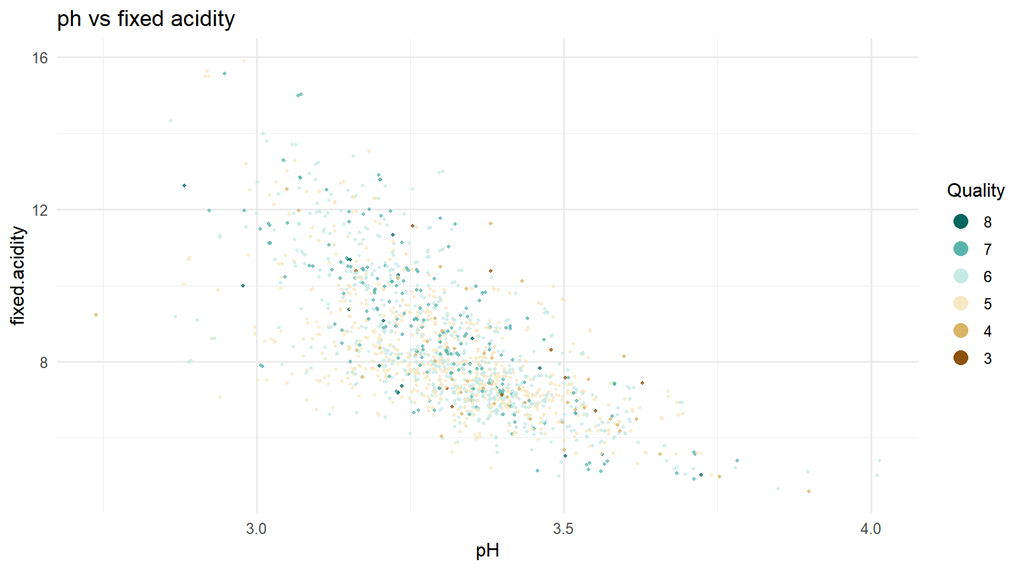

We plot the line plot with mean value of fixed acidity. The relative fixed acidity drastically decrease from 8 to under 6 around pH 3.5 in the quality level 8. Furthermore, quality level 8 has strongest negative correlation than others.

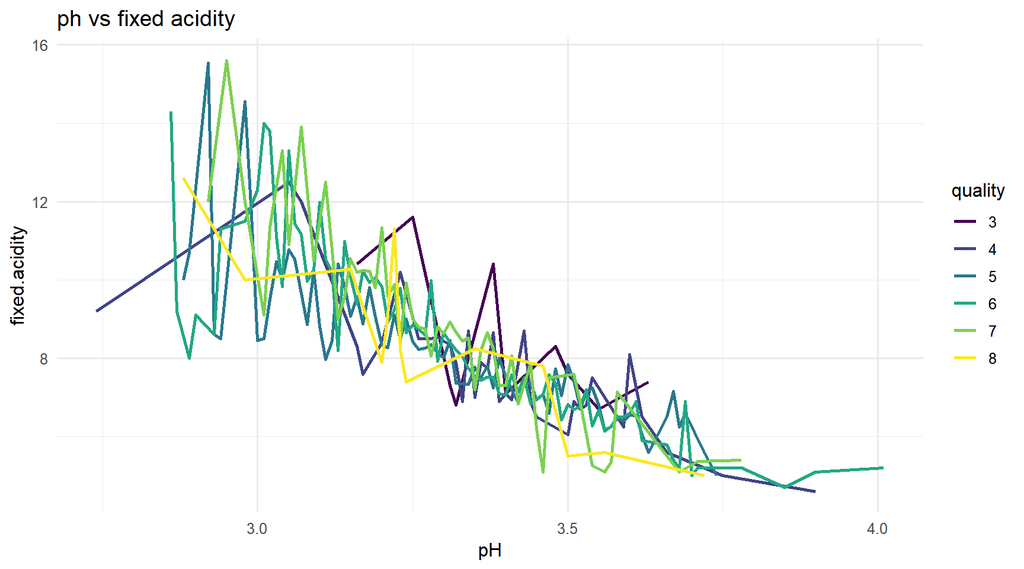

In the scatter plot of fixed acidiy to density, we can find that most quality level 5 wines are center around (x,y) = (7, 0.996), but it is relatively hard to find the relationship of others quality in this plot. let us check by line plot.

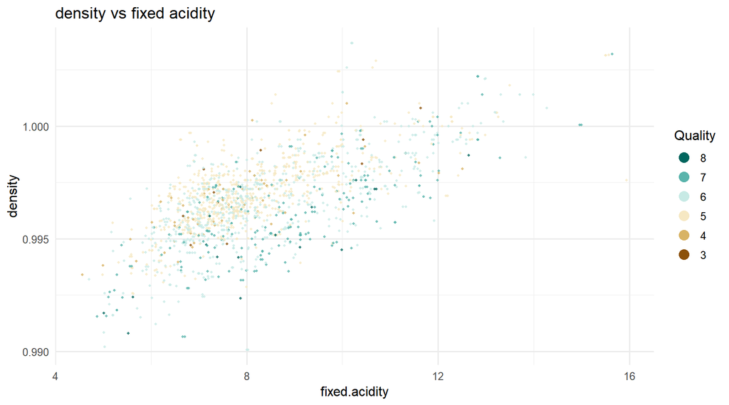

By line plot which x and y axis are fixed acidity are median of density, we can check few phenomenon when fixed acidity from near 8 to 10 in quality level 3, the density does not go upwpard. the other quailty level of wines shows the similar trend upward.

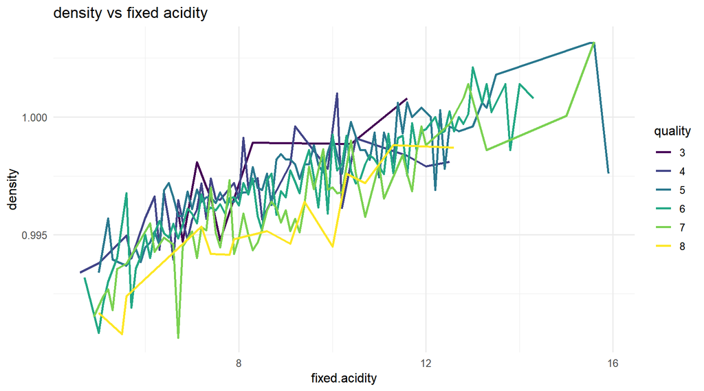

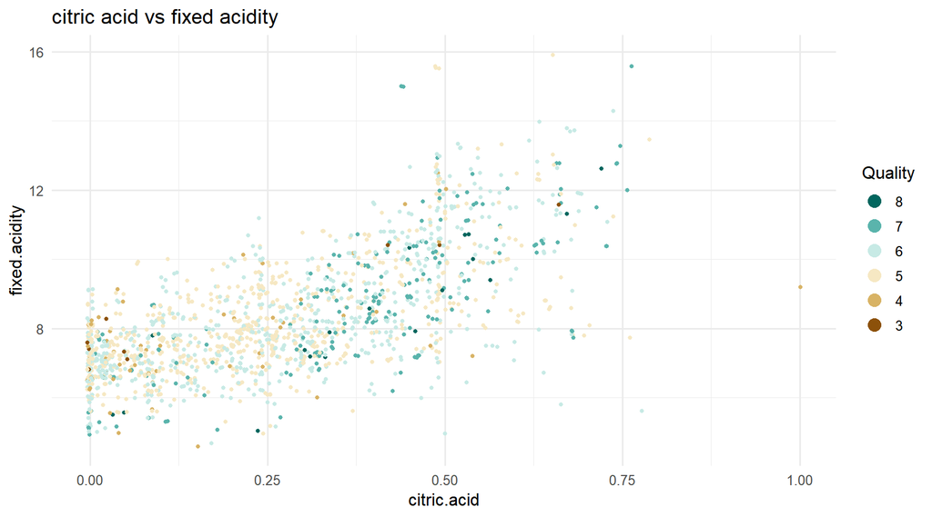

We also focus on the graph on pH to citric acid. Most quality level 5’s wine are distributed in lower place of citric acid than quality level 6.

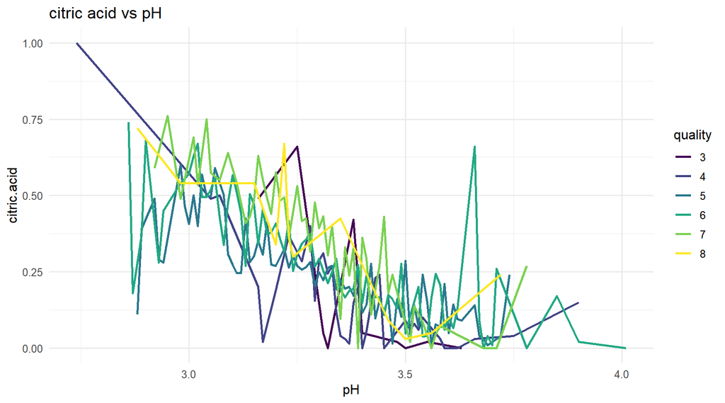

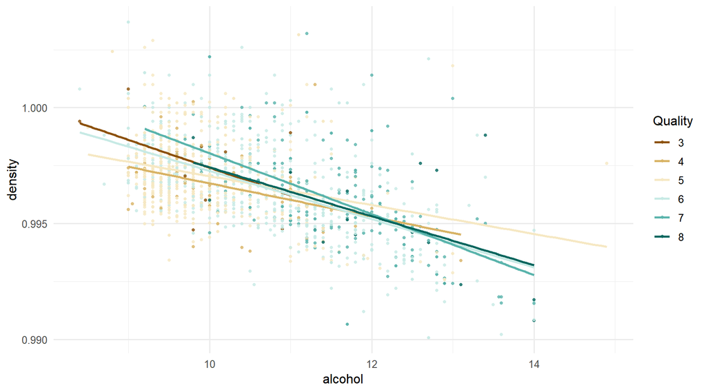

Based on the graph, alcohol plays a strong part in the quality of the wine.